# R course: Introduction to Bayesian GLMs

Below is a document of some basics, it would be good if you come understanding this (especially the ggplot and model plotting).

[Chris Brown](https://experts.griffith.edu.au/7867-chris-brown) chris.brown@griffith.edu.au

```r
library(simstudy)
library(brms)
library(dplyr)
```

```r
library(ggplot2)
library(patchwork)
theme_set(theme_classic())
```

## Using simstudy

Simulate some data, fish abundance vs SST.

We’ll go over `simstudy` package in the course too. But here’s how we’ll simulate data. I won’t assume you know this before hand, but you’ll get more out of the course if you look up the simstudy and read the intro vignette before hand

```r
vignette("simstudy",package = "simstudy")
```

Here’s how we simulate our data (in the course we’ll add REs too):

```r
def <- defData(varname = "sst", dist = "uniform", formula = "8;25") %>%
  defData(., varname = "fish", dist = "poisson",
    formula = " sst * 0.1", link = "log")
set.seed(42)
dat <- genData(50, def) %>%
  arrange(sst)
```

Plot the data we just generated

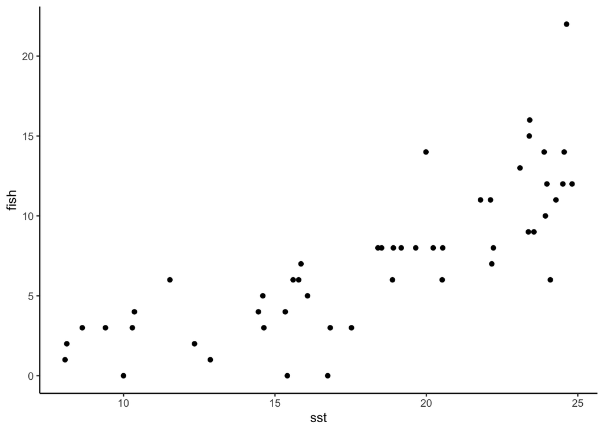

```r
ggplot(dat) +
  aes(x = sst, y = fish) +
  geom_point()
```

## Fitting a glm

Be great if everyone comes understanding these steps!

```r
m1 <- glm(fish ~ sst, family = poisson(link = "log"),
          data = dat)
coef(m1)
```

```
## (Intercept)         sst
##  -0.3893532   0.1213714
```

Predict from the GLM (ie what does the model predict mean abundance to be at the original SST measurements):

```r
pred_m1 <- predict(m1,
                        se = TRUE)

dat$pred_glm <- pred_m1$fit
dat$pred_glm_se <- pred_m1$se.fit
```

Code to plot predictions (mean + 95% CIs). Be great if you come understanding this ggplot syntax, so I don’t have to explain geoms, ribbons etc….

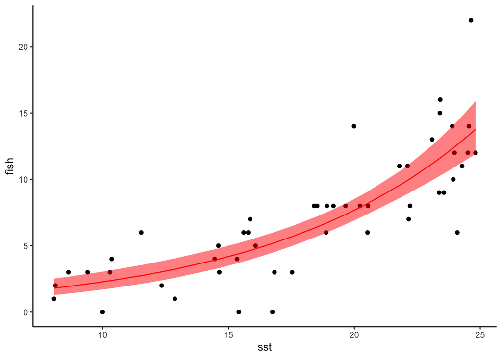

```r
g1 <- ggplot(dat) +
  aes(x = sst, y = fish) +
  geom_point() +
  geom_line(aes(y = exp(pred_glm)), color = "red") +
  geom_ribbon(aes(ymin = exp(pred_glm - pred_glm_se*1.96),
                  ymax = exp(pred_glm + pred_glm_se*1.96)),
              alpha = 0.5,
              fill = "red")

g1
```

I can explain why `exp(pred_glm - pred_glm_se*1.96)` gives the lower 95% CI in the workshop.

That’s it for assumed knowledge.